# Ejercicios

Author

Adrik Cornejo

# Objetos y estructuras de datos en R (3)

## Ejercicio 1: Vectores y selección

Crea los vectores ids = c(“g1”, “g2”, “g3”, “g4”, “g5”) y tam = c(90, 450, 310, 120, 600).

1. Selecciona el tercer identificador.
2. Recupera los identificadores de genes con longitud de al menos 300.
3. Cuenta cuántos cumplen esa condición sin usar un ciclo.

```r
ids <- c("g1", "g2", "g3", "g4", "g5")
tam <- c(90, 450, 310, 120, 600)

cat('\nEl tercer identificador es:', ids[3],
    '\nLos identificadores con longitud de al menos 300 son:', ids[tam>=300],
    '\nPor lo que', sum(tam>=300), 'identificadores cumplen la condicion.')
```

```
El tercer identificador es: g3
Los identificadores con longitud de al menos 300 son: g2 g3 g5
Por lo que 3 identificadores cumplen la condicion.
```

## Ejercicio 2: Factores

Crea una vector con las letras A M A B M M B A B B, donde A significa Alto, B bajo y M medio. Convierte las entradas del vector a factores y especifica que A > M > B.

```r
condicion <- factor(c("A", "M", "A", "B", "M", "M", "B", "A", "B", "B"),
                    levels = c("Alto", "Medio", "Bajo"))
levels(condicion)
```

```
[1] "Alto"  "Medio" "Bajo"
```

## Ejercicio 3: Elegir estructuras

1. Construye un `data.frame` con tres genes, sus longitudes y una etiqueta funcional.
2. Recupera únicamente las filas con longitud mayor que 200.
3. Crea una lista que contenga la tabla y el identificador de una muestra.
4. Explica por qué una matriz de caracteres no sería una buena sustitución para la tabla cuando queremos conservar longitudes numéricas.

```r
tabla <- data.frame(
  gen = c("g1", "g2", "g3"),
  longitud = c(100, 350, 500),
  funcion = c("hipotetica", "enzima", "transportador")
)

cat('\nLas filas con longitud mayor a 200 son:\n')
```

```
Las filas con longitud mayor a 200 son:
```

```r
tabla[tabla$longitud > 200, ]
```

```
  gen longitud       funcion
2  g2      350        enzima
3  g3      500 transportador
```

```r
resultado <- list(muestra = "M01", genes = tabla)
resultado$genes
```

```
  gen longitud       funcion
1  g1      100    hipotetica
2  g2      350        enzima
3  g3      500 transportador
```

```r
cat('\n\nUna matriz no seria una buena opcion debido a que en la matriz todo corresponde al mismo tipo de variable, no se puede combinar characters y numeros ')
```

```
Una matriz no seria una buena opcion debido a que en la matriz todo corresponde al mismo tipo de variable, no se puede combinar characters y numeros
```

# Estructuras de Control (4)

## Ejercicio 1: Clasificación de un valor

Define una variable conteo que represente el número de lecturas asignadas a un gen. Escribe un condicional que imprima

- `"Dato faltante"` si el valor es `NA`.
- `"Conteo inválido"` si es negativo.
- `"Sin lecturas"` si es cero.
- `"Con lecturas"` si es positivo.

```r
conteo = 0

if (is.na(conteo)) {
  print('Dato Faltante (NA)')
} else if (conteo < 0) {
  print('Conteo Invalido')
} else if (conteo == 0) {
  print('Sin lecturas')
} else {
  print('Con lecturas')
}
```

```
[1] "Sin lecturas"
```

## Ejercicio 2: Verificación de conteos

Considera el vector conteos = c(8, 0, 13, 5, 0, 21). Utiliza las funciones anteriores para:

1. Verificar si todos los valores son no negativos.
2. Determinar si existe al menos un conteo mayor que 20.
3. Obtener las posiciones de los conteos iguales a cero.
4. Crear un vector que indique `"Presente"` o `"Ausente"` según si el conteo es mayor que cero.

```r
conteos <- c(8, 0, 13, 5, 0, 21)

cat('\nLos conteos no son negativos:', all(conteos >= 0),
    '\nHay algun conteo mayor a 20?', any(conteos > 20),
    '\nQue conteos son exactamente 0?', which(conteos == 0),
    '\nVector que indica Presente o Ausente si el conteo es mayor a 0:\n',
    ifelse(conteos > 0, "Presente", "Ausente")
)
```

```
Los conteos no son negativos: TRUE
Hay algun conteo mayor a 20? TRUE
Que conteos son exactamente 0? 2 5
Vector que indica Presente o Ausente si el conteo es mayor a 0:
 Presente Ausente Presente Presente Ausente Presente
```

## Ejercicio 3: Longitudes de secuencias

A partir del vector: secuencias = c(“ATG”, “ATGCGT”, “AATTCCGG”, “CG”)

1. Utiliza un ciclo `for` para guardar las longitudes en un vector llamado `longitudes`.
2. Crea otro vector llamado `clasificacion` que contenga `"Corta"` para longitudes menores que 5 y `"Larga"` para longitudes de al menos 5.
3. Muestra ambos vectores.

```r
secuencias = c("ATG", "ATGCGT", "AATTCCGG", "CG")
long <- numeric(length(secuencias))
clasificacion <- character(length(secuencias))

for (i in seq_along(secuencias)){
  long[i] <- nchar(secuencias[i])

    if (long[i] < 5) {
    clasificacion[i] <- "Corta"
  } else {
    clasificacion[i] <- "Larga"
  }
}

cat('\nLas longitudes de las secuencias son, respectivamente: ', long, '\n', clasificacion)
```

```
Las longitudes de las secuencias son, respectivamente:  3 6 8 2
 Corta Larga Larga Corta
```

## Ejercicio 4: Alcanzar una longitud

Imagina que estamos construyendo una secuencia mediante la adición de un nucleótido “A” en cada iteración. Escribe un ciclo while que comience con una cadena vacía y se detenga cuando la secuencia alcance 8 nucleótidos. Muestra el resultado final.

```r
secuencia <- c('')
i = 1

  while (i<=8) {
    secuencia <- paste0(strrep("A", 1), secuencia)
    print(secuencia)
    i = i+1
  }
```

```
[1] "A"
[1] "AA"
[1] "AAA"
[1] "AAAA"
[1] "AAAAA"
[1] "AAAAAA"
[1] "AAAAAAA"
[1] "AAAAAAAA"
```

# Funciones en R (5)

## Ejercicio 1: Función 1

Escribe una función llamada empieza_con que reciba una secuencia y un prefijo, y determine si la secuencia comienza con ese prefijo. Pruébala con “ATGCGT” y los prefijos “ATG” y “TGA”.

```r
empieza_con <- function(secuencia, prefijo){
  startsWith(secuencia, prefijo)
}

cat('\nLa secuencia ATGCGT empieza con ATG?', empieza_con('ATGCGT', 'ATG'))
```

```
La secuencia ATGCGT empieza con ATG? TRUE
```

```r
cat('\nLa secuencia ATGCGT empieza con TGA?', empieza_con('ATGCGT', 'TGA'))
```

```
La secuencia ATGCGT empieza con TGA? FALSE
```

## Ejercicio 2: Función 2

Modifica resumir_adn() para que también devuelva la proporción de nucleótidos G y C respecto de la longitud total. Prueba la función con una secuencia no vacía.

```r
resumir_dna <- function(id, secuencia){
  secuencia = toupper(secuencia)
  longitud = nchar(secuencia)
  conteo.g = 0
  conteo.t = 0
  if (grepl('U', secuencia, fixed = TRUE) == TRUE) {
  tipo = 'Es RNA'
    } else {
  tipo = 'Es DNA'
    }
  conteo.g = (length(strsplit(secuencia, "G")[[1]]) -1)
  conteo.t = (length(strsplit(secuencia, "T")[[1]]) -1)
  conteo.gc = (conteo.g + conteo.t)/longitud

  list(id = id, tipo = tipo, longitud = longitud,
       Guanina = conteo.g, Timina = conteo.t, promedio.gc = conteo.gc)
}

resumir_dna('EPAS1', 'TTAA')
```

```
$id
[1] "EPAS1"

$tipo
[1] "Es DNA"

$longitud
[1] 4

$Guanina
[1] 0

$Timina
[1] 2

$promedio.gc
[1] 0.5
```

## Ejercicio 3: Función 3

Crea una función llamada clasificar_secuencias que reciba un vector de secuencias y devuelva una lista con dos elementos:

- `validas`: las secuencias formadas únicamente por `A`, `C`, `G` y `T`.
- `invalidas`: las secuencias que contienen otros caracteres o valores faltantes.

Utiliza la función `revisar_secuencias()` del ejemplo anterior.

```r
revisar_secuencias <- function(secuencias) {
  resultado <- logical(length(secuencias))

  for (i in seq_along(secuencias)) {
    secuencia <- secuencias[i]
    if (is.na(secuencia)) {
      resultado[i] <- FALSE
    } else {
      resultado[i] <- grepl("^[ACGT]+$", toupper(secuencia))
    }
  }

  resultado
}


clasificar_sec <- function(secuencias) {
  if (!is.character(secuencias)) {
    stop("El argumento debe ser un vector de tipo caracter")
  }

  es_valida <- sapply(secuencias, revisar_secuencias)

  validas <- secuencias[es_valida & !is.na(es_valida)]
  invalidas <- secuencias[!es_valida | is.na(es_valida)]

  return(list(validas = validas, invalidas = invalidas))
}

clasificar_sec(c("ATGCGT", "ACNTGA", "ttacga", NA))
```

```
$validas
[1] "ATGCGT" "ttacga"

$invalidas
[1] "ACNTGA" NA
```

## Ejercicio 4

Un archivo de secuencias ha sido representado en R mediante dos vectores:

ids = c(“seq_01”, “seq_02”, “seq_03”, “seq_04”) secuencias = c(“ATGCGT”, “ACNTGA”, “GGCCAA”, “TTTAAA”)

Escribe una función crear_reporte_secuencias(ids, secuencias) que:

1. Compruebe que ambos argumentos son vectores de caracteres y tienen la misma longitud.
2. Identifique las secuencias válidas mediante `revisar_secuencias()`.
3. Devuelva un `data.frame` con las columnas `id`, `secuencia`, `longitud` y `valida`.
4. Asigne `NA` a la longitud de las secuencias inválidas.

```r
crear_reporte_secuencias <- function(ids, secuencias) {
  lg_ids <- length(ids)
  lg_sec <- length(secuencias)

  if (lg_ids == lg_sec) {
    longitud_sec <- nchar(secuencias)

    clasificacion <- clasificar_sec(secuencias)

    es_valida <- secuencias %in% clasificacion$validas

    reporte <- data.frame(
      ID = ids,
      Secuencia = secuencias,
      Longitud = longitud_sec,
      Valida = es_valida,
      row.names = NULL
    )

    return(list(
      reporte = reporte,
      validas = clasificacion$validas,
      invalidas = clasificacion$invalidas
    ))
  } else {
    stop("Error: La cantidad de IDs y secuencias no coincide.")
  }
}

ids <- c("seq_01", "seq_02", "seq_03", "seq_04")
secuencias <- c("ATGCGT", "ACNTGA", "GGCCAA", "TTTAAA")

crear_reporte_secuencias(ids, secuencias)
```

```
$reporte
      ID Secuencia Longitud Valida
1 seq_01    ATGCGT        6   TRUE
2 seq_02    ACNTGA        6  FALSE
3 seq_03    GGCCAA        6   TRUE
4 seq_04    TTTAAA        6   TRUE

$validas
[1] "ATGCGT" "GGCCAA" "TTTAAA"

$invalidas
[1] "ACNTGA"
```

# Scripts, paquetes y proyectos de RStudio

## Ejercicio 1

Considera el siguiente código, guardado en un archivo llamado revision.R:

```r
# longitudes <- nchar(secuencias)
# resultado <- data.frame(id = ids, longitud = longitudes)
# print(resultado)
```

Un estudiante afirma que el archivo funciona porque obtuvo una tabla al ejecutarlo en su computadora.

1. ¿Por qué podría fallar si otra persona abre el archivo y lo ejecuta desde una sesión nueva de R? Básicamente falla porque aquí no se declara nunca la dichosa ‘secuencia’, por lo tanto ya la tenia guardada en su sesión pero si alguien mas lo corre no existe en su sesión.
2. ¿Cómo se puede modificar el script para que pueda ejecutarse completo sin depender de objetos creados previamente en la consola? O declarando la secuencia o en vez de poner secuencia como variable escribir la secuencia a usar.

# Importación y exploración de datos bioinformáticos en R (7)

## Ejercicio 1: Reconocer un archivo antes de importarlo

Sin abrirlo en una hoja de cálculo, utiliza R para comprobar que existe blast_separador_incorrecto.csv, mostrar sus tres primeras líneas y determinar qué separador utiliza realmente.

```r
library(readr)
library(dplyr)
library(tidyr)
library(tibble)

file.exists("~/Mate/Estadistica/BioinfoEst/data_raw/datos_sesion_02_blast/blast_separador_incorrecto.csv")
```

```
[1] TRUE
```

```r
blast <- read.csv("~/Mate/Estadistica/BioinfoEst/data_raw/datos_sesion_02_blast/blast_separador_incorrecto.csv")

cat('\nAl parecer a pesar de ser un .csv la separacion es por tabuladores:\n')
```

```
Al parecer a pesar de ser un .csv la separacion es por tabuladores:
```

```r
head(blast)
```

```
  query_id.subject_id.pident.length.evalue.bitscore
1        seq01\tref_001\t87.9\t216\t1.00e-40\t118.7
2        seq01\tref_002\t68.2\t245\t1.00e-36\t184.6
3        seq01\tref_003\t93.5\t168\t1.00e-35\t386.1
4        seq02\tref_004\t82.6\t111\t1.00e-85\t259.9
5        seq02\tref_005\t68.7\t292\t1.00e-57\t322.6
6        seq03\tref_007\t88.2\t254\t1.00e-05\t361.9
```

```r
blast_correcto <- read_tsv("~/Mate/Estadistica/BioinfoEst/data_raw/datos_sesion_02_blast/blast_separador_incorrecto.csv")
head(blast_correcto)
```

```
# A tibble: 6 × 6
  query_id subject_id pident length evalue bitscore
  <chr>    <chr>       <dbl>  <dbl>  <dbl>    <dbl>
1 seq01    ref_001      87.9    216  1e-40     119.
2 seq01    ref_002      68.2    245  1e-36     185.
3 seq01    ref_003      93.5    168  1e-35     386.
4 seq02    ref_004      82.6    111  1e-85     260.
5 seq02    ref_005      68.7    292  1e-57     323.
6 seq03    ref_007      88.2    254  1e- 5     362.
```

## Ejercicio 2: Elegir la función adecuada

Importa metadata_secuencias.csv y blast_comentarios.tsv utilizando readr. Conserva codigo_muestra como texto. Comprueba la clase de cada objeto y muestra sus primeras filas.

```r
blast <- read.delim('~/Mate/Estadistica/BioinfoEst/data_raw/datos_sesion_02_blast/resultados_blast.tsv')
metadata <- read.csv('~/Mate/Estadistica/BioinfoEst/data_raw/datos_sesion_02_blast/metadata_secuencias.csv',
                     colClasses = c(codigo_muestra = "character"))

glimpse(metadata)
```

```
Rows: 8
Columns: 4
$ query_id       <chr> "seq01", "seq02", "seq03", "seq04", "seq05", "seq06", "…
$ organismo      <chr> "Bacteria_A", "Bacteria_B", "Bacteria_C", "Bacteria_A",…
$ origen         <chr> "suelo", "agua", "suelo", "agua", "suelo", "agua", "sue…
$ codigo_muestra <chr> "001", "002", "003", "004", "005", "006", "007", "008"
```

```r
glimpse(blast)
```

```
Rows: 20
Columns: 6
$ query_id   <chr> "seq01", "seq01", "seq01", "seq02", "seq02", "seq03", "seq0…
$ subject_id <chr> "ref_001", "ref_002", "ref_003", "ref_004", "ref_005", "ref…
$ pident     <dbl> 87.9, 68.2, 93.5, 82.6, 68.7, 88.2, 93.6, 97.8, 99.0, 83.9,…
$ length     <int> 216, 245, 168, 111, 292, 254, 319, 191, 229, 162, 101, 306,…
$ evalue     <dbl> 1e-40, 1e-36, 1e-35, 1e-85, 1e-57, 1e-05, 1e-36, 1e-71, 1e-…
$ bitscore   <dbl> 118.7, 184.6, 386.1, 259.9, 322.6, 361.9, 96.6, 97.9, 335.9…
```

```r
head(metadata)
```

```
  query_id  organismo origen codigo_muestra
1    seq01 Bacteria_A  suelo            001
2    seq02 Bacteria_B   agua            002
3    seq03 Bacteria_C  suelo            003
4    seq04 Bacteria_A   agua            004
5    seq05 Bacteria_B  suelo            005
6    seq06 Bacteria_C   agua            006
```

```r
head(blast)
```

```
  query_id subject_id pident length evalue bitscore
1    seq01    ref_001   87.9    216  1e-40    118.7
2    seq01    ref_002   68.2    245  1e-36    184.6
3    seq01    ref_003   93.5    168  1e-35    386.1
4    seq02    ref_004   82.6    111  1e-85    259.9
5    seq02    ref_005   68.7    292  1e-57    322.6
6    seq03    ref_007   88.2    254  1e-05    361.9
```

## Ejercicio 3: Explorar resultados tipo BLAST

Con resultados_blast.tsv, responde mediante código:

1. ¿Cuántos registros y columnas tiene la tabla?
2. ¿Cuántos `query_id` diferentes aparecen?
3. ¿Cuántos resultados tiene cada consulta?
4. ¿Qué filas tienen `pident` mayor o igual a 95?
5. ¿Hay valores faltantes?

```r
blast_resultados <- readr::read_tsv('~/Mate/Estadistica/BioinfoEst/data_raw/datos_sesion_02_blast/resultados_blast.tsv', show_col_types = FALSE)

cat('\nEspecificaciones del dataset')
```

```
Especificaciones del dataset
```

```r
readr::spec(blast_resultados)
cat('\nFilas y resulados\n')
```

```
Filas y resulados
```

```r
nrow(blast_resultados)
```

```
[1] 20
```

```r
nrow(blast_resultados) * 4
```

```
[1] 80
```

```r
unique(blast_resultados$query_id)
```

```
[1] "seq01" "seq02" "seq03" "seq04" "seq05" "seq06" "seq07" "seq08"
```

```r
sort(table(blast_resultados$query_id), decreasing = TRUE)
```

```
seq03 seq01 seq05 seq07 seq02 seq06 seq08 seq04
    4     3     3     3     2     2     2     1
```

```r
cat('\nPident mayor o igual a 95')
```

```
Pident mayor o igual a 95
```

```r
blast_resultados[blast_resultados$pident >= 95,]
```

```
# A tibble: 3 × 6
  query_id subject_id pident length evalue bitscore
  <chr>    <chr>       <dbl>  <dbl>  <dbl>    <dbl>
1 seq03    ref_009      97.8    191  1e-71     97.9
2 seq03    ref_010      99      229  1e- 8    336.
3 seq07    ref_019      95.7    106  1e-70    138.
```

```r
cat('\nHay NAs?')
```

```
Hay NAs?
```

```r
anyNA(blast_resultados)
```

```
[1] FALSE
```

## Ejercicio 4: Detectar un problema de lectura

Un estudiante importa blast_separador_incorrecto.csv con read_csv() y obtiene una sola columna. ¿Significa que el archivo contiene una única variable? Explica cómo comprobarlo y corrige la importación. No realmente, puede ser que uso un separador distinto pese a ser terminacion .csv

```r
ruta <- '~/Mate/Estadistica/BioinfoEst/data_raw/datos_sesion_02_blast/blast_separador_incorrecto.csv'
mal <- readr::read_csv(ruta)
head(mal)
```

```
# A tibble: 6 × 1
  `query_id\tsubject_id\tpident\tlength\tevalue\tbitscore`
  <chr>
1 "seq01\tref_001\t87.9\t216\t1.00e-40\t118.7"
2 "seq01\tref_002\t68.2\t245\t1.00e-36\t184.6"
3 "seq01\tref_003\t93.5\t168\t1.00e-35\t386.1"
4 "seq02\tref_004\t82.6\t111\t1.00e-85\t259.9"
5 "seq02\tref_005\t68.7\t292\t1.00e-57\t322.6"
6 "seq03\tref_007\t88.2\t254\t1.00e-05\t361.9"
```

```r
bien <- readr::read_tsv(ruta, show_col_types = FALSE)
head(bien)
```

```
# A tibble: 6 × 6
  query_id subject_id pident length evalue bitscore
  <chr>    <chr>       <dbl>  <dbl>  <dbl>    <dbl>
1 seq01    ref_001      87.9    216  1e-40     119.
2 seq01    ref_002      68.2    245  1e-36     185.
3 seq01    ref_003      93.5    168  1e-35     386.
4 seq02    ref_004      82.6    111  1e-85     260.
5 seq02    ref_005      68.7    292  1e-57     323.
6 seq03    ref_007      88.2    254  1e- 5     362.
```

## Ejercicio 5: Reconocer secuencias en FASTA

Utiliza `readLines()` y `grep()` para identificar los encabezados de secuencias.fasta. ¿Cuántas entradas FASTA contiene el archivo? Muestra únicamente sus encabezados.

```r
FASTA <- readLines("~/Mate/Estadistica/BioinfoEst/data_raw/datos_sesion_02_blast/secuencias.fasta")
cat('\n\nEl archivo FASTA con longitud:', nrow(FASTA) )
```

```
El archivo FASTA con longitud:
```

```r
cat('\nCon un total de encabezados:', length(grep('^>', FASTA, value = TRUE)),
    '\nEncabezados del archivo FASTA:\n')
```

```
Con un total de encabezados: 8
Encabezados del archivo FASTA:
```

```r
grep('^>', FASTA, value = TRUE)
```

```
[1] ">seq01 secuencia_sintetica" ">seq02 secuencia_sintetica"
[3] ">seq03 secuencia_sintetica" ">seq04 secuencia_sintetica"
[5] ">seq05 secuencia_sintetica" ">seq06 secuencia_sintetica"
[7] ">seq07 secuencia_sintetica" ">seq08 secuencia_sintetica"
```

## Ejercicio 6: De los archivos a una descripción de los datos

Crea un script llamado `02_exploracion.R` dentro de tu proyecto. El script debe:

1. Comprobar que existen `resultados_blast.tsv`, `metadata_secuencias.csv` y `secuencias.fasta`.
2. Importar las dos tablas con `readr` y conservar `codigo_muestra` como texto.
3. Mostrar dimensiones, nombres y tipos de columnas.
4. Identificar los `query_id` distintos y contar los resultados por consulta.
5. Mostrar las filas con `pident >= 90` y explicar qué representa este filtro.
6. Leer el FASTA e indicar cuántos encabezados contiene.
7. Mostrar si alguna de las tablas tiene valores faltantes.

Escribe al final del script, como comentarios, **tres observaciones sobre la estructura de los datos**, sin extraer conclusiones biológicas.

```r
# 02_Exploracion

file.exists("~/Mate/Estadistica/BioinfoEst/data_raw/datos_sesion_02_blast/resultados_blast.tsv")
```

```
[1] TRUE
```

```r
file.exists("~/Mate/Estadistica/BioinfoEst/data_raw/datos_sesion_02_blast/metadata_secuencias.csv")
```

```
[1] TRUE
```

```r
file.exists("~/Mate/Estadistica/BioinfoEst/data_raw/datos_sesion_02_blast/secuencias.fasta")
```

```
[1] TRUE
```

```r
rst_blast <- read_tsv("~/Mate/Estadistica/BioinfoEst/data_raw/datos_sesion_02_blast/resultados_blast.tsv")
sec_metadata <- read.csv("~/Mate/Estadistica/BioinfoEst/data_raw/datos_sesion_02_blast/metadata_secuencias.csv")
FASTA <- readLines("~/Mate/Estadistica/BioinfoEst/data_raw/datos_sesion_02_blast/secuencias.fasta")


cat('\n\nLas dimesiones del archivo resultados_blast.tsv son:',
    '\nFilas:', nrow(rst_blast), '\nColumnas:', ncol(rst_blast))
```

```
Las dimesiones del archivo resultados_blast.tsv son:
Filas: 20
Columnas: 6
```

```r
cat('\nCon columnas con nombres:')
```

```
Con columnas con nombres:
```

```r
spec(rst_blast)
cat('\nCon query id:')
```

```
Con query id:
```

```r
sort(table(rst_blast$query_id), decreasing = TRUE)
```

```
seq03 seq01 seq05 seq07 seq02 seq06 seq08 seq04
    4     3     3     3     2     2     2     1
```

```r
cat('\nFilas significativas (>= 90):')
```

```
Filas significativas (>= 90):
```

```r
rst_blast[rst_blast$pident >= 90,]
```

```
# A tibble: 5 × 6
  query_id subject_id pident length evalue bitscore
  <chr>    <chr>       <dbl>  <dbl>  <dbl>    <dbl>
1 seq01    ref_003      93.5    168  1e-35    386.
2 seq03    ref_008      93.6    319  1e-36     96.6
3 seq03    ref_009      97.8    191  1e-71     97.9
4 seq03    ref_010      99      229  1e- 8    336.
5 seq07    ref_019      95.7    106  1e-70    138.
```

```r
cat('\nLo que significa que hay una alineacion significativa y que es poco
    probable que las alineaciones hayan ocurrido por azar')
```

```
Lo que significa que hay una alineacion significativa y que es poco
    probable que las alineaciones hayan ocurrido por azar
```

```r
cat('\n\nLas dimesiones del archivo metadata_secuencias.csv son:',
    '\nFilas:', nrow(sec_metadata), '\nColumnas:', ncol(sec_metadata))
```

```
Las dimesiones del archivo metadata_secuencias.csv son:
Filas: 8
Columnas: 4
```

```r
cat('\nCon columnas con nombres:')
```

```
Con columnas con nombres:
```

```r
spec_csv("~/Mate/Estadistica/BioinfoEst/data_raw/datos_sesion_02_blast/metadata_secuencias.csv")
cat('\nCon query id:')
```

```
Con query id:
```

```r
sort(table(sec_metadata$query_id), decreasing = TRUE)
```

```
seq01 seq02 seq03 seq04 seq05 seq06 seq07 seq08
    1     1     1     1     1     1     1     1
```

```r
cat('\nCon origenes:')
```

```
Con origenes:
```

```r
unique(sec_metadata$origen)
```

```
[1] "suelo" "agua"
```

```r
cat('\n\nEl archivo FASTA con longitud:', nrow(FASTA) )
```

```
El archivo FASTA con longitud:
```

```r
cat('\nCon un total de encabezados:', length(grep('^>', FASTA, value = TRUE)),
    '\nEncabezados del archivo FASTA:')
```

```
Con un total de encabezados: 8
Encabezados del archivo FASTA:
```

```r
grep('^>', FASTA, value = TRUE)
```

```
[1] ">seq01 secuencia_sintetica" ">seq02 secuencia_sintetica"
[3] ">seq03 secuencia_sintetica" ">seq04 secuencia_sintetica"
[5] ">seq05 secuencia_sintetica" ">seq06 secuencia_sintetica"
[7] ">seq07 secuencia_sintetica" ">seq08 secuencia_sintetica"
```

```r
cat('Ninguno de los archivos presenta NAs:', anyNA(FASTA),
    anyNA(rst_blast),
    anyNA(sec_metadata))
```

```
Ninguno de los archivos presenta NAs: FALSE FALSE FALSE
```

# Manipulación y transformación de datos bioinformáticos con dplyr y tidyr

## Ejercicio 1. Identificación de genes candidatos

Queremos explorar qué genes podrían estar relacionados con la respuesta bacteriana al estrés.

Utilizando dplyr:

1. Calcula el conteo promedio de cada gen en cada condición experimental.
2. Organiza los resultados de manera que puedas comparar los promedios de Control y Estrés para cada gen.
3. Calcula la razón entre el promedio en Estrés y el promedio en Control.
4. Identifica los cinco genes con mayor aumento relativo y muestra su anotación funcional.

```r
datos <- read.csv(
  "~/Mate/Estadistica/BioinfoEst/data_raw/expresion_genica_estres.csv",
)

glimpse(datos)
```

```
Rows: 240
Columns: 8
$ sample_id     <chr> "CTL_01", "CTL_02", "CTL_03", "EST_01", "EST_02", "EST_0…
$ condicion     <chr> "Control", "Control", "Control", "Estres", "Estres", "Es…
$ replica       <int> 1, 2, 3, 1, 2, 3, 1, 2, 3, 1, 2, 3, 1, 2, 3, 1, 2, 3, 1,…
$ gene_id       <chr> "gene_001", "gene_001", "gene_001", "gene_001", "gene_00…
$ funcion       <chr> "Función desconocida", "Función desconocida", "Función d…
$ longitud_pb   <int> 1803, 1803, 1803, 1803, 1803, 1803, 891, 891, 891, 891, …
$ gc_porcentaje <dbl> 58.1, 58.1, 58.1, 58.1, 58.1, 58.1, 43.2, 43.2, 43.2, 43…
$ conteo        <int> 1302, 1263, 1368, 892, 953, 1106, 639, 998, 1108, 733, 9…
```

```r
media_1 <- datos %>%
  group_by(gene_id, condicion) %>%
  summarise(media = mean(conteo, na.rm = TRUE), .groups = "drop")
media_1
```

```
# A tibble: 80 × 3
   gene_id  condicion media
   <chr>    <chr>     <dbl>
 1 gene_001 Control   1311
 2 gene_001 Estres     984.
 3 gene_002 Control    915
 4 gene_002 Estres     907.
 5 gene_003 Control    927.
 6 gene_003 Estres    1041.
 7 gene_004 Control   1260.
 8 gene_004 Estres    1799.
 9 gene_005 Control    108.
10 gene_005 Estres     167
# ℹ 70 more rows
```

```r
# Checa esto -->
razon_genes <- datos %>%
  group_by(gene_id, condicion) %>%
  summarise(media = mean(conteo, na.rm = TRUE), .groups = "drop") %>%
  mutate(media = media) %>%
  pivot_wider(names_from = condicion, values_from = media) %>%
  mutate(razon_estres_control = Estres / Control) %>%
  select(gene_id, razon_estres_control)
razon_genes
```

```
# A tibble: 40 × 2
   gene_id  razon_estres_control
   <chr>                   <dbl>
 1 gene_001                0.750
 2 gene_002                0.992
 3 gene_003                1.12
 4 gene_004                1.43
 5 gene_005                1.54
 6 gene_006                2.07
 7 gene_007                2.88
 8 gene_008                4.33
 9 gene_009                6.50
10 gene_010                0.442
# ℹ 30 more rows
```

```r
top5_genes <- datos %>%
  group_by(gene_id, funcion, condicion) %>%
  summarise(media = mean(conteo), .groups = "drop") %>%
  pivot_wider(names_from = condicion, values_from = media) %>%
  mutate(razon_estres_control = Estres / Control) %>%
  arrange(desc(razon_estres_control)) %>%
  slice_head(n = 5)
top5_genes
```

```
# A tibble: 5 × 5
  gene_id  funcion                  Control Estres razon_estres_control
  <chr>    <chr>                      <dbl>  <dbl>                <dbl>
1 gene_009 Transporte de membrana      179.  1162.                 6.50
2 gene_029 Metabolismo energético      237.  1318.                 5.57
3 gene_039 Metabolismo energético      312   1717.                 5.50
4 gene_028 Replicación y reparación    452   2127.                 4.71
5 gene_019 Transporte de membrana      868.  4020.                 4.63
```

¿Un gen con un aumento relativo grande necesariamente presenta un conteo alto de lecturas?

## Ejercicio 2. ¿Qué funciones biológicas predominan?

Queremos investigar cuáles son las funciones biológicas representadas entre los genes con mayores conteos de lecturas.

Utilizando dplyr:

1. Calcula el conteo promedio de cada gen considerando todas las muestras.
2. Identifica los 15 genes con mayor conteo promedio.
3. Determina cuántos de esos genes pertenecen a cada categoría funcional.
4. Ordena las categorías funcionales de mayor a menor frecuencia.

```r
# 02

media_2 <- datos %>%
  group_by(gene_id) %>%
  summarise(media = mean(conteo),
            .groups = "drop") %>%
  mutate(tot_media = media) %>%
  select(gene_id, tot_media) %>%
  arrange(desc(tot_media)) %>%
  slice_head(n = 15)
media_2
```

```
# A tibble: 15 × 2
   gene_id  tot_media
   <chr>        <dbl>
 1 gene_018     2990.
 2 gene_008     2548.
 3 gene_019     2444
 4 gene_017     1807.
 5 gene_026     1669.
 6 gene_036     1585.
 7 gene_004     1530.
 8 gene_023     1463.
 9 gene_007     1456.
10 gene_006     1451.
11 gene_024     1445.
12 gene_015     1410.
13 gene_028     1290.
14 gene_032     1240.
15 gene_001     1147.
```

```r
cat_fun <- datos %>%
    filter(gene_id %in% media_2$gene_id) %>%
    group_by(funcion) %>%
    summarise(
    n_distinct(funcion))
cat_fun
```

```
# A tibble: 8 × 2
  funcion                    `n_distinct(funcion)`
  <chr>                                      <int>
1 Función desconocida                            1
2 Metabolismo de aminoácidos                     1
3 Metabolismo energético                         1
4 Regulación transcripcional                     1
5 Replicación y reparación                       1
6 Respuesta al estrés                            1
7 Síntesis de proteínas                          1
8 Transporte de membrana                         1
```

## Ejercicio 3: ¿Qué genes destacan dentro de cada muestra?

En un experimento de expresión génica, algunos genes pueden presentar conteos considerablemente mayores que otros dentro de una misma muestra.

Queremos identificar los genes cuyos conteos superan el promedio de su propia muestra.

Utilizando dplyr:

1. Calcula el conteo promedio de los genes en cada muestra.
2. Agrega a la tabla original una columna llamada `promedio_muestra` que contenga ese promedio para cada observación, **sin eliminar ninguna fila**.
3. Identifica los genes cuyo conteo sea al menos el doble del promedio de su muestra.
4. Calcula cuántos genes cumplen esta condición en cada muestra y compara los resultados entre Control y Estrés.

```r
media_cont <- datos %>%
  group_by(gene_id) %>%
  mutate(
    promedio_muestra = mean(conteo, na.rm = TRUE),
    promediox2 = promedio_muestra * 2
  ) %>%
  ungroup() %>%
  mutate(
    supera = conteo >= promediox2,
    etiqueta = if_else(supera, "Superior", "Inferior")
  ) %>%
  select(gene_id, funcion, condicion, supera)

media_cont
```

```
# A tibble: 240 × 4
   gene_id  funcion                    condicion supera
   <chr>    <chr>                      <chr>     <lgl>
 1 gene_001 Función desconocida        Control   FALSE
 2 gene_001 Función desconocida        Control   FALSE
 3 gene_001 Función desconocida        Control   FALSE
 4 gene_001 Función desconocida        Estres    FALSE
 5 gene_001 Función desconocida        Estres    FALSE
 6 gene_001 Función desconocida        Estres    FALSE
 7 gene_002 Metabolismo de aminoácidos Control   FALSE
 8 gene_002 Metabolismo de aminoácidos Control   FALSE
 9 gene_002 Metabolismo de aminoácidos Control   FALSE
10 gene_002 Metabolismo de aminoácidos Estres    FALSE
# ℹ 230 more rows
```

```r
resumen_muestras <- media_cont %>%
  group_by(gene_id, condicion) %>%
  summarise(
    Supera = sum(supera, na.rm = TRUE),
    .groups = "drop"
  )

resumen_muestras
```

```
# A tibble: 80 × 3
   gene_id  condicion Supera
   <chr>    <chr>      <int>
 1 gene_001 Control        0
 2 gene_001 Estres         0
 3 gene_002 Control        0
 4 gene_002 Estres         0
 5 gene_003 Control        0
 6 gene_003 Estres         0
 7 gene_004 Control        0
 8 gene_004 Estres         0
 9 gene_005 Control        0
10 gene_005 Estres         0
# ℹ 70 more rows
```

¿Por qué es más adecuado comparar cada gen con el promedio de su propia muestra en lugar de utilizar un único promedio calculado con todas las muestras? Para poder comparar la expresion especifica del gen y no el promedio total, y asi poder ver el aumento o decremento de acuerdo a ese gen y no se vea alterado por otra cosa.

# Integración de datos y automatización de análisis en R (9)

## 9.8 Actividad breve: ¿la tabla está lista para graficarse?

Sin construir otra función, revisa generos_5 y responde:

1. ¿Qué representa una fila de generos_5? Los datos de la muestra
2. ¿Por qué un mismo género puede aparecer individualmente en una muestra y dentro de Otros en otra? Un mismo genero aparece separado en una muestra y agrupado en “Otros” en otra debido al umbral de abundancia relativa usado para visualizar los datos
3. Si construimos una gráfica de barras apiladas al 100 %, ¿cuánto deben sumar las abundancias relativas de cada muestra? Deberian sumar entre todas 1 o 100%
4. ¿Qué columna nos permite comparar las muestras según la planta hospedera? ¿De dónde proviene? `host_name`

```r
generos_5 <- read_tsv('resultados/generos_5.tsv')

generos_5 %>%
  group_by(sample_id) %>%
  summarise(total = sum(abundancia_relativa), .groups = "drop")
```

```
# A tibble: 75 × 2
   sample_id   total
   <chr>       <dbl>
 1 ERR5639101      1
 2 SRR11092499     1
 3 SRR11092502     1
 4 SRR11092506     1
 5 SRR11092508     1
 6 SRR11092509     1
 7 SRR11092511     1
 8 SRR11092512     1
 9 SRR11128412     1
10 SRR11128413     1
# ℹ 65 more rows
```

# Construcción y exploración visual de datos bioinformáticos con ggplot2 (10)

## 10.12.1 Ejercicio 1:

Utilizando generos_5 y metadata_riz:

Identifica las plantas hospederas que tienen al menos 5 muestras.

Conserva únicamente las muestras correspondientes a esas plantas.

Construye una gráfica de barras apiladas de abundancia relativa por género con ggplot2, utilizando facet_wrap() para comparar las plantas hospederas.

Personaliza la figura con una paleta de colores adecuada, etiquetas legibles y la categoría “Géneros < 5%” al final de la leyenda.

Para discutir: ¿Qué diferencias observas en la composición taxonómica entre las plantas? ¿Todas las muestras de una misma planta presentan composiciones similares?

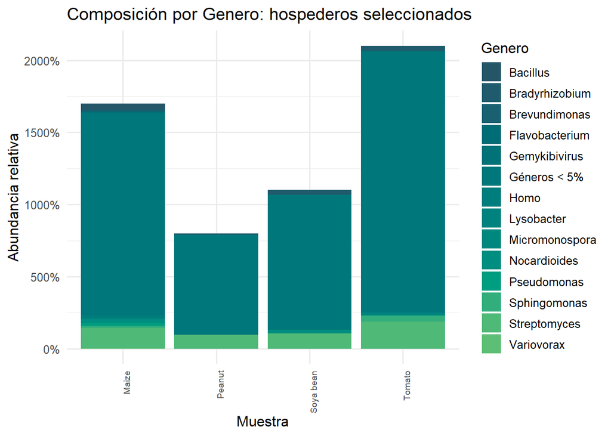

```r
library(ggplot2)

metadata_riz <- read_csv(
  "data_raw/datos_rizosfera/metadata_rizosfera.csv"
)
generos_5 <- read_tsv("resultados/generos_5.tsv")
filos_5 <- read_tsv("resultados/filos_5.csv")
totales_muestra <- read_tsv("resultados/tot_muestras.tsv")

orden_filos <- c(
  sort(setdiff(unique(filos_5$taxon_final), "Filos < 5%")),
  "Filos < 5%"
)

orden_generos <- c(
  sort(setdiff(unique(generos_5$taxon_final), "Géneros < 5%")),
  "Géneros < 5%"
)

colores <- as.character(
  paletteer::paletteer_c("grDevices::ag_GrnYl", 30)
)

hospederos <- metadata_riz %>%
  count(host_name) %>%
  filter(n >= 5) %>%
  pull(host_name)

mas_5 <- generos_5 %>%
  filter(host_name %in% hospederos)


p_5 <- ggplot(mas_5,
              aes(x = host_name, y = abundancia_relativa,
                  fill = taxon_final)
) +
  geom_col() +
  scale_fill_manual(values = colores,
                    breaks = orden_filos) +
  scale_y_continuous(labels = function(x) paste0(round(100 * x), "%")) +
  labs(title = "Composición por Genero: hospederos seleccionados",
       x = "Muestra", y = "Abundancia relativa", fill = "Genero") +
  theme_minimal(base_size = 12) +
  theme(axis.text.x = element_text(angle = 90, hjust = 1, size = 7))

p_5
```

## 10.12.2 Ejercicio 2:

Utilizando filos_5 y metadata_riz:

Identifica los países que tienen al menos 5 muestras.

Conserva únicamente las muestras correspondientes a esos países.

Construye una gráfica de barras apiladas de abundancia relativa por filo con ggplot2, utilizando facet_wrap() para comparar los países.

Para discutir: ¿Qué diferencias observas en la composición taxonómica entre los países? ¿Las muestras de un mismo país presentan composiciones similares?

```r
pais <- metadata_riz %>%
  count(country) %>%
  filter(n >= 5) %>%
  pull(country)

al_menos_5 <- metadata_riz %>%
  filter(country %in% pais)
al_menos_5
```

```
# A tibble: 65 × 22
   sample_id   experiment  assay_type seq_type plant_part  host_name_order
   <chr>       <chr>       <chr>      <chr>    <chr>       <chr>
 1 SRR12192850 SRX8706683  WGS        Shotgun  Rhizosphere Poales
 2 SRR13062011 SRX9510017  WGS        other    Rhizosphere Poales
 3 SRR11128413 SRX7764931  WGS        PCR      Rhizosphere Poales
 4 SRR12964294 SRX9416888  WGS        Shotgun  Rhizosphere Poales
 5 SRR12192805 SRX8706634  WGS        Shotgun  Rhizosphere Poales
 6 SRR8197395  SRX5016769  WGS        Shotgun  Rhizosphere Poales
 7 SRR11092511 SRX7731320  WGS        Shotgun  Rhizosphere Poales
 8 SRR14320329 SRX10675467 WGS        RANDOM   Rhizosphere Poales
 9 SRR12192851 SRX8706682  WGS        Shotgun  Rhizosphere Poales
10 SRR13062099 SRX9510111  WGS        other    Rhizosphere Poales
# ℹ 55 more rows
# ℹ 16 more variables: host_name_family <chr>, host_name_genus <chr>,
#   host_name_specie <chr>, host_name <chr>, crop_system <chr>, latitude <dbl>,
#   longitude <dbl>, state <chr>, country <chr>, continent <chr>, doi <chr>,
#   year <dbl>, depth_all_biom <dbl>, depth_rank <dbl>,
#   fraction_resolved <dbl>, depth_final <dbl>
```

[figure not shown]

```r
filos_actualizado <- filos_5 %>%
  left_join(select(al_menos_5, sample_id, country), by = "sample_id")

filos <- na.omit(filos_actualizado)

c_5 <- ggplot(filos,
              aes(x = sample_id, y = abundancia_relativa,
                  fill = taxon_final)
) +
  geom_col() +
  scale_fill_manual(values = colores,
                    breaks = orden_filos) +
  scale_y_continuous(labels = function(x) paste0(round(100 * x), "%")) +
  labs(title = "Composición por Pais: muestras seleccionadas",
       x = "Muestra", y = "Abundancia relativa", fill = "taxon_final") +
  theme_minimal(base_size = 12) +
  theme(axis.text.x = element_text(angle = 90, hjust = 1, size = 7))

c_5
```